# COVID-19 Communication Guideline

## Introduction

COVID-19 is likely to bring us a range of difficult communication scenarios that we have to address with patients and relatives. The staff working in the Clinical Services Department (CSD) will have a varied amount of training in communication skills previously so this guideline will provide a simple overview to support staff. It will also detail the specific communication processes in place for COVID-19 during a surge in capacity where patients will be cohorted and relatives’ access to patients and communication with clinical staff will be restricted.

## Target User

- All CSD staff

## Target area of use

- Ward

## Key areas of focus / New additions / Changes

This guidelines provides generic communication tools and examples of phrasing for difficult conversations and information about the Family Liaison Team who will support communication with relatives.

## Limitations

COVID-19 is a rapidly evolving situation and processes on CSD may have to adapt depending on what stage of the pandemic we are in as well as staffing levels.

## Generic Communication Tools

When approaching a patient or relative to break bad news or discuss a sensitive topic, there are some simple tools which can help. ‘SPIKES’ was developed and validated as a tool for disclosing unfavourable information to cancer patients about their illness initially, but has been used since then more broadly for breaking bad news. There have been a number of alternative mnemonics discussed in the literature but they are mostly quite similar to SPIKES which is clear and easy to understand.

> **S** Setting and situation: choose the most private and comfortable setting available, sit down if possible.

> **P** Perceptions: uncover what the patient and/or family think is happening.

> **I** Invitation: ask the patient and/or family what they would like to know.

> **K** Knowledge: explain the disease and care options in simple language, address any concerns.

> **E** Empathy: respect feelings and respond with empathy.

> **S** Summary and strategy: summarise and decide plan for what is next.

### Examples of phrasing

When communicating with relatives and patients you should use **simple language** with **no medical jargon**. **Speak slowly** and **use pauses** to give people a chance to process what they are hearing. Ensure you **listen** to what the relatives or patients are saying, acknowledge that you have heard them and show **empathy** when appropriate. Always check that people have understood what you have said by asking them to **summarise** back to you what they have understood from your conversation.

Below are some examples of how you might phrase some conversations. It is important to find phrasing that feels natural to you and to focus on positives where possible. Instead of saying things such as ‘there’s nothing more that we can do’, try saying ‘we are doing everything we can to make your relative feel more comfortable’. It can also be useful to deflect some negativity on COVID-19 itself so instead of saying ‘it is MRC’s policy that we don’t allow visitors on the ward’ you could say ‘I’m so sorry you can’t visit your relative but this disease is so infectious and dangerous that you need to stay safe at home.’

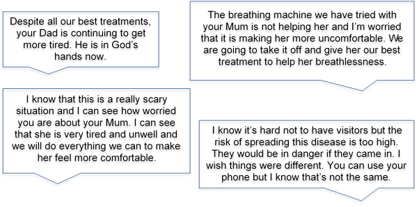

## Family Liaison Team

The Family Liaison Team will consist MRC staff who are not working on the front line but are senior in cultural authority. They will be focused on assisting with communicating to families during the COVID-19 response.

1. To counsel families as their relative is admitted on the communication procedures of CSD (See appendix 1).
   - One family member is to be nominated as the primary point of contact and their name and contact details to be taken and uploaded onto EMRS.
   - One family member to be identified as the person to contact for a patient visit if their relative becomes very tired and is deteriorating rapidly.
2. To give telephone updates daily to families of patients who are very unwell or unconscious.
   - Doctors and nurses to allocate an ‘update status’ for each patient daily when on the ward round which the Family Liaison Team can use. See below for full details.

To receive calls from relatives and respond to any questions or concerns surrounding routine care of patients with COVID-19. The team will have a ‘Frequently Asked Questions’ document with scripted responses to cover topics such as what COVID-19 is, how COVID-19 progresses etc.

3. To call families when their relative is identified as becoming very tired and deteriorating rapidly for the nominated family member to attend for a visit for up to one hour each day.
   - Family Liaison Team will advise relative to bring a bag with a towel and soap.
   - They will then brief the relative on PPE and what to expect. The relative will put on cotton scrubs and give their bag with belongings to the Family Liaison Team member with a name label on.
   - They will help the relative to don PPE then wait for them to complete their visit on the ward.
   - They will then advise them from 2 m away on the process of doffing PPE then escort them back to the changing room with their bag of belongings so they can shower then get dressed back in their own clothes.
4. To call family members when their relative has died unexpectedly. This will involve breaking the bad news as well as informing them about how deaths are managed (the role of the Red Cross) and what will happen next.
5. To inform families about planned discharges from the ward.
   - The team will ask a family member to bring in fresh clothes (and shoes if possible).
   - They will answer questions about infection risk, COVID-19 etc

**Daily Update Status**

Clinical staff will document daily for each patient on their clinical category as follows:

- **Improving**

Patient is improving and will be ready for discharge soon.

- **Stable**

Patient is stable – neither improving nor getting worse, but we are not concerned about them at present.

- **Concern**

Patient is not making progress or responding well to medical interventions, we are concerned they may deteriorate despite maximal treatment.

- **Deteriorating**

Patient is getting worse despite receiving all possible treatments. They may not survive.

A member of the Family Liaison Team will then ring the allocated primary contact relative to update them using the script detailed in Appendix 2. When the relative has been successfully contacted then this will be documented in EMRS.

The contacts for the Family Liaison Team will be made available in the clinical area when they are needed.

## Key Issues for Nursing care

Liaise with the Family Liaison Team when necessary and ensure a relative’s contact details are appropriately recorded on EMRS.

## References

Baile, W.F., Buckman, R., Lenzi, R., Glober, G., Beale, E.A. and Kudelka, A.P. (2000), SPIKES—A Six‐Step Protocol for Delivering Bad News: Application to the Patient with Cancer. The Oncologist, 5: 302-311. doi:10.1634/theoncologist.5-4-302

| **Written by:** | Name: Daisy Taylor | Date: 29 April 2020 |
| --- | --- | --- |
| **Reviewed by:** | Name: Karen Forrest, Helen Brotherton, Effua Usuf | Date: 08 May 2020 |
| **Reviewed by:** | Name: Karen Forrest | Date: 26 August 2020 |
| **Version:** | **Change history:** | **Review due date:** |
| 1.0 | New document | 08 May 2022 |
| 2.0 | Addition of responsibilities around death and discharge | 26 August 2022 |
| Review Comments (*if applicable)* |  |  |

When a new admission arrives on the ward, please ensure the following details are taken and added to EMRS.

| Name of patient & MRC number |  |
| --- | --- |
| Name of primary point of contact for family |  |
| Relationship to patient |  |
| Telephone numbers of primary point of contact |  |
| Name of escort who will visit the ward in case of deterioration |  |
| Telephone numbers of escort who will visit the ward in case of deterioration |  |

Please also explain to the relatives the following procedures.

1. Relatives can bring in a small bag for the patient containing a mobile phone, charger, change of clothes and any other small items that they may require. The bag should have a label with the patient’s name on it.
2. Explain daily update status procedures.
3. Give primary point of contact for the family the contact details for the Family Liaison Team.

## Appendix 2 – Family Liaison Team script for the daily update status

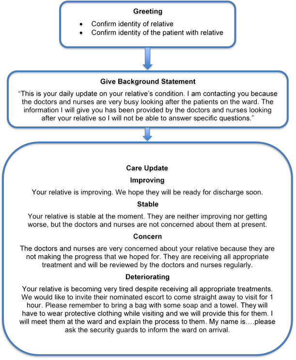